# Projeto de Decreto Legislativo 394/2024

05-12-2024

## **Projeto de Decreto Legislativo 394/2024 (PDL 394/2024). MENSAGEM Nº 482/2023 - reconhecimento recíproco e outorga de matrículas para o exercício profissional na esfera dos serviços de arquitetura e outros.**

### Sumário

##### Sobre a proposição

##### Tramitação

##### Histórico

##### Perfil dos parlamentares

### Sobre a proposição

O Projeto de Decreto Legislativo 394/2024 [(PDL 394/2024)](https://www.camara.leg.br/proposicoesWeb/prop_mostrarintegra?codteor=2828713&filename=PDL%20394/2024) dispõe sobre a aprovação do trata do **Acordo Marco do MERCOSUL de Reconhecimento Recíproco e Outorga de Matrículas para o Exercício Profissional Temporário da Agrimensura, Agronomia, Arquitetura, Geologia e Engenharia, assinado em Montevidéu, em 6 de julho de 2022**.

O acordo corrobora com a [Decisão 25/03](http://www.sice.oas.org/trade/mrcsrs/decisions/dec2503p.asp) do Conselho do Mercado Comum, de 15 de dezembro de 2003, incorporada ao ordenamento jurídico brasileiro pelo Decreto n° 9.499, de 10 de setembro de 2018. A Decisão dispõe sobre outorga de licenças temporárias aos prestadores de serviços profissionais nos Estados Partes.

### Tramitação

O PDL 394/2024 deriva da Mensagem de Acordos, convênios, tratados e atos internacionais 482/2023 [(MSC 482/2023)](https://www.camara.leg.br/proposicoesWeb/prop_mostrarintegra?codteor=2332622&filename=MSC%20482/2023), do Poder Executivo.

De acordo com a Constituição Federal de 1988, cabe ao Congresso Nacional *resolver definitivamente sobre tratados, acordos ou atos internacionais que acarretem encargos ou compromissos gravosos ao patrimônio nacional*;

Nesse sentido, a Mensagem foi enviada ao Congresso Nacional para aprovação do Acordo Marco.

Após aprovada na Comissão de Representação Brasileira no Parlamento do Mercosul a MSC 482/2023 foi transformada no PDL 394/2024. Agora a proposição deve ser aprovada nas comissões afins na Câmara dos Deputados e no Senado Federal.

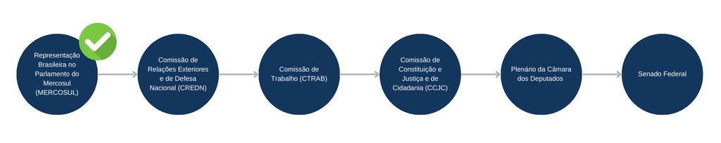

### Histórico

##### *Dezembro/2021*

Acordo Marco MERCOSUL de reconhecimento recíproco e outorga de matrículas para o exercício profissional temporário da agrimensura, agronomia, arquitetura, geologia e engenharia foi aprovado em reunião ordinária do Conselho do Mercado Comum;

##### *Junho/2022*

Conselho do Mercado Comum apresenta o texto do Acordo Marco;

##### *Setembro/2023*

MSC 482/2023 é enviada do Poder Executivo para o Congresso Nacional;

##### *Abril/2024*

CAU/BR conversa com relator da matéria, Heitor Schuch (PSB-RS), para indicar a importância da aprovação do Acordo Marco;

##### *Junho/2024*

Relator, Deputado Heitor Schuch (PSB-RS), apresenta parecer pela aprovação;

##### *Outubro/2024*

CAU/BR tem [reunião com o Presidente da Comissão de Representação Brasileira no Parlamento do Mercosul](https://caubr.gov.br/cau-br-pede-agilidade-em-acordo-do-mercosul-para-mobilidade-de-arquitetos/#:~:text=O%20pacto%2C%20assinado%20em%20Montevid%C3%A9u,entre%20os%20pa%C3%ADses%20do%20bloco.), Senador Nelsinho Trad (PSD/MS) para solicitar que a MSC 482/2023 fosse pautada na próxima reunião;

##### *Novembro/2024*

Parecer é aprovado e a mensagem é transformada em projeto de Projeto de Decreto Legislativo;

##### *Dezembro/2024*

Enviados ofícios de agradecimento ao Deputado Heitor Schuch e ao Senador Nelsinho Trad pelo apoio na aprovação da MSC 482/2023.

### Perfil dos Parlamentares

#### **Heitor Schuch**

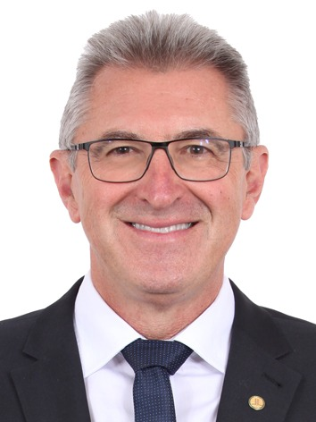

- Atividade parlamentar (Câmara dos Deputados): 2015-atual;
- Profissão: agricultor;
- Também foi deputado estadual (2003-2015) no Rio Grande do Sul;
- Coautor do requerimento para criação das frentes parlamentares (1) de Defesa do Patrimônio Histórico e Cultural Brasileiro, (2) apoio à Regularização Fundiária, Desenvolvimento Habitacional e Desenvolvimento Urbano Sustentável, (3) pelos Centros Urbanos, (4) de Defesa do Sistema de Modelagem da Informação da Construção (BIM), (5) de Defesa do Serviço Público, (6) para o Fomento da Qualificação, Inclusão e Subsistência das Mulheres na Construção Civil, (7) para o Fortalecimento da Gestão Pública, (8) de Defesa das Cidades Históricas e (9) de Defesa do Gerenciamento e Gestão Integrada de Resíduos Sólidos;
- Também é autor de dois projetos de lei relevantes: [PL 1422/2019](https://www.camara.leg.br/proposicoesWeb/fichadetramitacao?idProposicao=2193767), [PL 1279/2022](https://www.camara.leg.br/proposicoesWeb/fichadetramitacao?idProposicao=2323493).

Voltar à leitura

#### **Nelsinho Trad**

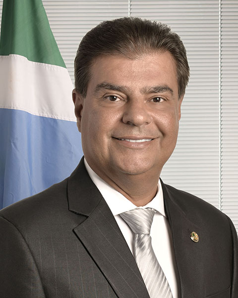

- Atividade parlamentar (Senado Federal): 2018-atual;
- Profissão: médico;
- Também foi vereador (1992-2002), deputado estadual (2002-2005) e prefeito (2005-2013) em Campo Grande (MS);
- Autor de cinco proposições relevantes: [PEC 13/2024](https://www25.senado.leg.br/web/atividade/materias/-/materia/163043), [PEC 80/2019](https://www25.senado.leg.br/web/atividade/materias/-/materia/136894), PEC 167/2019, [PL 4392/2021](https://www.camara.leg.br/proposicoesWeb/fichadetramitacao?idProposicao=2315066), [RQS 1095/2023](https://www25.senado.leg.br/web/atividade/materias/-/materia/161554).

Voltar à leitura